# Project 1: Solving Data Science Problems

São Paulo, 03 September of 2019  
Felipe Mahlmeister

1. Import Data
2. Visualizing & Cleaning Data
3. Imputation & Feature Engineering
4. Data Exploration
5. Data Preprocessing
6. Model Selection & Hyperparameter Tuning
7. Ensembling Models
8. Model Predictions
9. Submission

## 1. Import Data

```python
# Import Libraries
import numpy as np
import pandas as pd

import matplotlib.pyplot as plt
import seaborn as sns

from datetime import datetime

from scipy import stats
from scipy.stats import norm, skew, boxcox_normmax
from scipy.special import boxcox1p

from sklearn.preprocessing import RobustScaler
from sklearn.model_selection import KFold, cross_val_score
from sklearn.metrics import mean_squared_error
from sklearn.linear_model import ElasticNetCV, LassoCV, RidgeCV
from sklearn.ensemble import RandomForestRegressor
from sklearn.pipeline import make_pipeline
from xgboost import XGBRegressor

sns.set(style="whitegrid")
pd.set_option('display.max_columns', 500)
pd.set_option('display.max_rows', 500)
%matplotlib inline
```

```python
# import requests, zipfile, io
# url = 'https://storage.googleapis.com/kaggle-competitions-data/kaggle/5407/205873/all.zip?GoogleAccessId=web-data@kaggle-161607.iam.gserviceaccount.com&Expires=1567182986&Signature=ckJVtll9bHZiNTPSd0XRGkmaiWneoC3AW7XYvGUeDxMe%2BM0WqoiZlBZAJKjCO5ceAWk8kYX2R9UHe%2FSMiunT5do3NF%2B58S3SHPVwIZN9zp1n9CLtVBkf5MGZO2MpHjmMP2CqU4BCq6VXXgJwbDLa5oWMX5%2BNkMCh3xhFdz4RXdhBzJYUMn1ovGLv9sL1tHMol5O3xA8JSG7uiWxcQt5vDbxGo8VOXyHKIB8N7xDMN2sK2PspSjlZNfky1JhZncG7TXABaWOlZE5wpY9sfewMlr8%2BiogzuUltEAzFWtgRTeqT%2F7pzqyHxRMszo2Yr0dvekRJgFfWS7zDQKkk%2BQu9XCA%3D%3D&response-content-disposition=attachment%3B+filename%3Dhouse-prices-advanced-regression-techniques.zip'
# r = requests.get(url)
# z = zipfile.ZipFile(io.BytesIO(r.content))
# z.extractall('source')
```

```python
train = pd.read_csv('source/train.csv')
test = pd.read_csv('source/test.csv')
print("imported data")
print("Train set size:", train.shape)
print("Test set size:", test.shape)
```

```
imported data
Train set size: (1460, 81)
Test set size: (1459, 80)
```

```python
train.head()
```

|  | Id | MSSubClass | MSZoning | LotFrontage | LotArea | Street | Alley | LotShape | LandContour | Utilities | LotConfig | LandSlope | Neighborhood | Condition1 | Condition2 | BldgType | HouseStyle | OverallQual | OverallCond | YearBuilt | YearRemodAdd | RoofStyle | RoofMatl | Exterior1st | Exterior2nd | MasVnrType | MasVnrArea | ExterQual | ExterCond | … |
| --- | --- | --- | --- | --- | --- | --- | --- | --- | --- | --- | --- | --- | --- | --- | --- | --- | --- | --- | --- | --- | --- | --- | --- | --- | --- | --- | --- | --- | --- | --- |
| 0 | 1 | 60 | RL | 65.0 | 8450 | Pave | NaN | Reg | Lvl | AllPub | Inside | Gtl | CollgCr | Norm | Norm | 1Fam | 2Story | 7 | 5 | 2003 | 2003 | Gable | CompShg | VinylSd | VinylSd | BrkFace | 196.0 | Gd | TA | … |
| 1 | 2 | 20 | RL | 80.0 | 9600 | Pave | NaN | Reg | Lvl | AllPub | FR2 | Gtl | Veenker | Feedr | Norm | 1Fam | 1Story | 6 | 8 | 1976 | 1976 | Gable | CompShg | MetalSd | MetalSd | None | 0.0 | TA | TA | … |
| 2 | 3 | 60 | RL | 68.0 | 11250 | Pave | NaN | IR1 | Lvl | AllPub | Inside | Gtl | CollgCr | Norm | Norm | 1Fam | 2Story | 7 | 5 | 2001 | 2002 | Gable | CompShg | VinylSd | VinylSd | BrkFace | 162.0 | Gd | TA | … |
| 3 | 4 | 70 | RL | 60.0 | 9550 | Pave | NaN | IR1 | Lvl | AllPub | Corner | Gtl | Crawfor | Norm | Norm | 1Fam | 2Story | 7 | 5 | 1915 | 1970 | Gable | CompShg | Wd Sdng | Wd Shng | None | 0.0 | TA | TA | … |
| 4 | 5 | 60 | RL | 84.0 | 14260 | Pave | NaN | IR1 | Lvl | AllPub | FR2 | Gtl | NoRidge | Norm | Norm | 1Fam | 2Story | 8 | 5 | 2000 | 2000 | Gable | CompShg | VinylSd | VinylSd | BrkFace | 350.0 | Gd | TA | … |

```python
test.head()
```

|  | Id | MSSubClass | MSZoning | LotFrontage | LotArea | Street | Alley | LotShape | LandContour | Utilities | LotConfig | LandSlope | Neighborhood | Condition1 | Condition2 | BldgType | HouseStyle | OverallQual | OverallCond | YearBuilt | YearRemodAdd | RoofStyle | RoofMatl | Exterior1st | Exterior2nd | MasVnrType | MasVnrArea | ExterQual | ExterCond | … |
| --- | --- | --- | --- | --- | --- | --- | --- | --- | --- | --- | --- | --- | --- | --- | --- | --- | --- | --- | --- | --- | --- | --- | --- | --- | --- | --- | --- | --- | --- | --- |
| 0 | 1461 | 20 | RH | 80.0 | 11622 | Pave | NaN | Reg | Lvl | AllPub | Inside | Gtl | NAmes | Feedr | Norm | 1Fam | 1Story | 5 | 6 | 1961 | 1961 | Gable | CompShg | VinylSd | VinylSd | None | 0.0 | TA | TA | … |
| 1 | 1462 | 20 | RL | 81.0 | 14267 | Pave | NaN | IR1 | Lvl | AllPub | Corner | Gtl | NAmes | Norm | Norm | 1Fam | 1Story | 6 | 6 | 1958 | 1958 | Hip | CompShg | Wd Sdng | Wd Sdng | BrkFace | 108.0 | TA | TA | … |
| 2 | 1463 | 60 | RL | 74.0 | 13830 | Pave | NaN | IR1 | Lvl | AllPub | Inside | Gtl | Gilbert | Norm | Norm | 1Fam | 2Story | 5 | 5 | 1997 | 1998 | Gable | CompShg | VinylSd | VinylSd | None | 0.0 | TA | TA | … |
| 3 | 1464 | 60 | RL | 78.0 | 9978 | Pave | NaN | IR1 | Lvl | AllPub | Inside | Gtl | Gilbert | Norm | Norm | 1Fam | 2Story | 6 | 6 | 1998 | 1998 | Gable | CompShg | VinylSd | VinylSd | BrkFace | 20.0 | TA | TA | … |
| 4 | 1465 | 120 | RL | 43.0 | 5005 | Pave | NaN | IR1 | HLS | AllPub | Inside | Gtl | StoneBr | Norm | Norm | TwnhsE | 1Story | 8 | 5 | 1992 | 1992 | Gable | CompShg | HdBoard | HdBoard | None | 0.0 | Gd | TA | … |

## 2. Visualizing & Cleaning Data

Let's take a deeper look at the train dataset

```python
train.describe()
```

|  | Id | MSSubClass | LotFrontage | LotArea | OverallQual | OverallCond | YearBuilt | YearRemodAdd | MasVnrArea | BsmtFinSF1 | BsmtFinSF2 | BsmtUnfSF | TotalBsmtSF | 1stFlrSF | 2ndFlrSF | LowQualFinSF | GrLivArea | BsmtFullBath | BsmtHalfBath | FullBath | HalfBath | BedroomAbvGr | KitchenAbvGr | TotRmsAbvGrd | Fireplaces | GarageYrBlt | GarageCars | GarageArea | WoodDeckSF | … |
| --- | --- | --- | --- | --- | --- | --- | --- | --- | --- | --- | --- | --- | --- | --- | --- | --- | --- | --- | --- | --- | --- | --- | --- | --- | --- | --- | --- | --- | --- | --- |
| count | 1460.000000 | 1460.000000 | 1201.000000 | 1460.000000 | 1460.000000 | 1460.000000 | 1460.000000 | 1460.000000 | 1452.000000 | 1460.000000 | 1460.000000 | 1460.000000 | 1460.000000 | 1460.000000 | 1460.000000 | 1460.000000 | 1460.000000 | 1460.000000 | 1460.000000 | 1460.000000 | 1460.000000 | 1460.000000 | 1460.000000 | 1460.000000 | 1460.000000 | 1379.000000 | 1460.000000 | 1460.000000 | 1460.000000 | … |
| mean | 730.500000 | 56.897260 | 70.049958 | 10516.828082 | 6.099315 | 5.575342 | 1971.267808 | 1984.865753 | 103.685262 | 443.639726 | 46.549315 | 567.240411 | 1057.429452 | 1162.626712 | 346.992466 | 5.844521 | 1515.463699 | 0.425342 | 0.057534 | 1.565068 | 0.382877 | 2.866438 | 1.046575 | 6.517808 | 0.613014 | 1978.506164 | 1.767123 | 472.980137 | 94.244521 | … |
| std | 421.610009 | 42.300571 | 24.284752 | 9981.264932 | 1.382997 | 1.112799 | 30.202904 | 20.645407 | 181.066207 | 456.098091 | 161.319273 | 441.866955 | 438.705324 | 386.587738 | 436.528436 | 48.623081 | 525.480383 | 0.518911 | 0.238753 | 0.550916 | 0.502885 | 0.815778 | 0.220338 | 1.625393 | 0.644666 | 24.689725 | 0.747315 | 213.804841 | 125.338794 | … |
| min | 1.000000 | 20.000000 | 21.000000 | 1300.000000 | 1.000000 | 1.000000 | 1872.000000 | 1950.000000 | 0.000000 | 0.000000 | 0.000000 | 0.000000 | 0.000000 | 334.000000 | 0.000000 | 0.000000 | 334.000000 | 0.000000 | 0.000000 | 0.000000 | 0.000000 | 0.000000 | 0.000000 | 2.000000 | 0.000000 | 1900.000000 | 0.000000 | 0.000000 | 0.000000 | … |
| 25% | 365.750000 | 20.000000 | 59.000000 | 7553.500000 | 5.000000 | 5.000000 | 1954.000000 | 1967.000000 | 0.000000 | 0.000000 | 0.000000 | 223.000000 | 795.750000 | 882.000000 | 0.000000 | 0.000000 | 1129.500000 | 0.000000 | 0.000000 | 1.000000 | 0.000000 | 2.000000 | 1.000000 | 5.000000 | 0.000000 | 1961.000000 | 1.000000 | 334.500000 | 0.000000 | … |
| 50% | 730.500000 | 50.000000 | 69.000000 | 9478.500000 | 6.000000 | 5.000000 | 1973.000000 | 1994.000000 | 0.000000 | 383.500000 | 0.000000 | 477.500000 | 991.500000 | 1087.000000 | 0.000000 | 0.000000 | 1464.000000 | 0.000000 | 0.000000 | 2.000000 | 0.000000 | 3.000000 | 1.000000 | 6.000000 | 1.000000 | 1980.000000 | 2.000000 | 480.000000 | 0.000000 | … |
| 75% | 1095.250000 | 70.000000 | 80.000000 | 11601.500000 | 7.000000 | 6.000000 | 2000.000000 | 2004.000000 | 166.000000 | 712.250000 | 0.000000 | 808.000000 | 1298.250000 | 1391.250000 | 728.000000 | 0.000000 | 1776.750000 | 1.000000 | 0.000000 | 2.000000 | 1.000000 | 3.000000 | 1.000000 | 7.000000 | 1.000000 | 2002.000000 | 2.000000 | 576.000000 | 168.000000 | … |
| max | 1460.000000 | 190.000000 | 313.000000 | 215245.000000 | 10.000000 | 9.000000 | 2010.000000 | 2010.000000 | 1600.000000 | 5644.000000 | 1474.000000 | 2336.000000 | 6110.000000 | 4692.000000 | 2065.000000 | 572.000000 | 5642.000000 | 3.000000 | 2.000000 | 3.000000 | 2.000000 | 8.000000 | 3.000000 | 14.000000 | 3.000000 | 2010.000000 | 4.000000 | 1418.000000 | 857.000000 | … |

```python
train.info(memory_usage='deep')
```

```
<class 'pandas.core.frame.DataFrame'>
RangeIndex: 1460 entries, 0 to 1459
Data columns (total 81 columns):
Id               1460 non-null int64
MSSubClass       1460 non-null int64
MSZoning         1460 non-null object
LotFrontage      1201 non-null float64
LotArea          1460 non-null int64
Street           1460 non-null object
Alley            91 non-null object
LotShape         1460 non-null object
LandContour      1460 non-null object
Utilities        1460 non-null object
LotConfig        1460 non-null object
LandSlope        1460 non-null object
Neighborhood     1460 non-null object
Condition1       1460 non-null object
Condition2       1460 non-null object
BldgType         1460 non-null object
HouseStyle       1460 non-null object
OverallQual      1460 non-null int64
OverallCond      1460 non-null int64
YearBuilt        1460 non-null int64
YearRemodAdd     1460 non-null int64
RoofStyle        1460 non-null object
RoofMatl         1460 non-null object
Exterior1st      1460 non-null object
Exterior2nd      1460 non-null object
MasVnrType       1452 non-null object
MasVnrArea       1452 non-null float64
ExterQual        1460 non-null object
ExterCond        1460 non-null object
Foundation       1460 non-null object
BsmtQual         1423 non-null object
BsmtCond         1423 non-null object
BsmtExposure     1422 non-null object
BsmtFinType1     1423 non-null object
BsmtFinSF1       1460 non-null int64
BsmtFinType2     1422 non-null object
BsmtFinSF2       1460 non-null int64
```

[output cut: 31 more lines]

```
EnclosedPorch    1460 non-null int64
3SsnPorch        1460 non-null int64
ScreenPorch      1460 non-null int64
PoolArea         1460 non-null int64
PoolQC           7 non-null object
Fence            281 non-null object
MiscFeature      54 non-null object
MiscVal          1460 non-null int64
MoSold           1460 non-null int64
YrSold           1460 non-null int64
SaleType         1460 non-null object
SaleCondition    1460 non-null object
SalePrice        1460 non-null int64
dtypes: float64(3), int64(35), object(43)
memory usage: 3.9 MB
```

As the PK of both datasets has nothing to aggregate in our analysis, we'll separate them for now

```python
train_ID = train['Id']
test_ID = test['Id']

train.drop(['Id'], axis=1, inplace=True)
test.drop(['Id'], axis=1, inplace=True)
```

## 3. Imputation & Feature Engineering

#### Concatenation

To keep consistency between test and train features we concatenate the two sets while remembering the index so we can split it later again.

```python
y_train = train.SalePrice.reset_index(drop=True)
n_train = train.shape[0]
train_features = train.drop(['SalePrice'], axis=1).copy()
test_features = test.copy()

# concatenate the train and the test set as features for tranformation to avoid mismatch
features = pd.concat([train_features, test_features]).reset_index(drop=True)
print('Features size:', features.shape)
```

```
Features size: (2919, 79)
```

#### Missing values

Let's find the percentage of missing data in each column and determine whether the threshold of missing values is acceptable or not.

```python
# missing data percent plot
total_features = features.isnull().sum().sort_values(ascending=False)
percent_features = (features.isnull().sum()/features.isnull().count()).sort_values(ascending=False)
missing_data = pd.concat([total_features, percent_features], axis=1, keys=['Total', 'Percent'])
missing_data.head(20)
```

|  | Total | Percent |
| --- | --- | --- |
| PoolQC | 2909 | 0.996574 |
| MiscFeature | 2814 | 0.964029 |
| Alley | 2721 | 0.932169 |
| Fence | 2348 | 0.804385 |
| FireplaceQu | 1420 | 0.486468 |
| LotFrontage | 486 | 0.166495 |
| GarageCond | 159 | 0.054471 |
| GarageQual | 159 | 0.054471 |
| GarageYrBlt | 159 | 0.054471 |
| GarageFinish | 159 | 0.054471 |
| GarageType | 157 | 0.053786 |
| BsmtCond | 82 | 0.028092 |
| BsmtExposure | 82 | 0.028092 |
| BsmtQual | 81 | 0.027749 |
| BsmtFinType2 | 80 | 0.027407 |
| BsmtFinType1 | 79 | 0.027064 |
| MasVnrType | 24 | 0.008222 |
| MasVnrArea | 23 | 0.007879 |
| MSZoning | 4 | 0.001370 |
| BsmtHalfBath | 2 | 0.000685 |

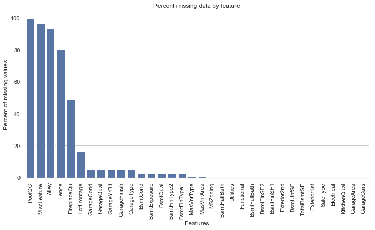

```python
# Setting to the variable no_color
base_color = sns.color_palette()[0]

# Initialize the matplotlib figure
f, ax = plt.subplots(figsize=(12, 6))
plt.xticks(rotation="90")
sns.barplot(x=missing_data[missing_data['Percent']>0]['Percent'].index,
            y=missing_data[missing_data['Percent']>0]['Percent']*100,
            color=base_color)

# Labels and legend
ax.set(ylabel="Percent of missing values")
ax.set(xlabel="Features")

# Plot title
ax.set(title="Percent missing data by feature")
sns.despine(left=True)
plt.show()
```

These visualisation helps determine which values need to be imputed, We impute them by proceeding sequentially through features with missing values.

#### Imputation (Filling in Missing Values)

```python
# fill missing value by the median of all neighborhood
features.LotFrontage.fillna(features.LotFrontage.median(), inplace=True)

# Replacing missing data with 0 (Since No garage = no cars in such garage.)
gar_num = ['GarageYrBlt','GarageArea','GarageCars']
features.loc[:,gar_num] = features.loc[:,gar_num].fillna(0)

# Replacing missing data with None
gar_cat = ['GarageType','GarageFinish','GarageQual','GarageCond']
features.loc[:,gar_cat] = features.loc[:,gar_cat].fillna('None')

# Fill in with the most frequent value (mode)
features.Exterior1st.fillna(features.Exterior1st.mode()[0], inplace=True)
features.Exterior2nd.fillna(features.Exterior2nd.mode()[0], inplace=True)
features.MSZoning.fillna(features.MSZoning.mode()[0], inplace=True)
features.SaleType.fillna(features.SaleType.mode()[0], inplace=True)

# data description says NA means "No Pool", majority of houses have no Pool at all in general.
features.PoolQC.fillna('None')

# data description says NA means typical
features.Functional.fillna('Typ', inplace=True)

# has one NA value. Since this feature has mostly 'SBrkr', we can set that for the missing value.
features.Electrical.fillna('SBrkr', inplace=True)

#  Only one NA value, We set 'TA' (which is the most frequent) for the missing value in KitchenQual
features.KitchenQual.fillna('TA', inplace=True)

# Fill in the missing values for all of the categorical variables that don't exist
cat_missing = ['MiscFeature', 'Alley', 'Fence', 'FireplaceQu',
               'MasVnrType','MSSubClass','Utilities','BsmtQual','PoolQC',
               'BsmtCond', 'BsmtExposure','BsmtFinType1','BsmtFinType2']

features.loc[:,cat_missing] = features.loc[:,cat_missing].fillna('None')

# Fill in the missing values for numerical variables
num_missing = ['BsmtFinSF1','BsmtFinSF2','BsmtUnfSF','TotalBsmtSF',
               'BsmtFullBath','BsmtHalfBath','MasVnrArea']

features.loc[:,num_missing] = features.loc[:,num_missing].fillna(0)
```

```python
#Check for any more missing values
features.isnull().any().sum()
```

```
0
```

Great! We filled in all of our missing values.

Now we just have a few little final changes to make before our data is ready to be used to build a model. First, we will ensure that all numeric values are being represented as integers, and ensure that the other attributes are represented as categorical.

In sequence, we are going to make sure that all of our variables are in a form that the machine learning algorithms can use. We are going to do that by enconding categorical variables.

```python
to_int = ['LotFrontage','LotArea','OverallQual','OverallCond',
          'YearBuilt','YearRemodAdd','MasVnrArea','BsmtFinSF1',
          'BsmtFinSF2','BsmtUnfSF','TotalBsmtSF','1stFlrSF',
          '2ndFlrSF','LowQualFinSF','GrLivArea','BsmtFullBath',
          'BsmtHalfBath','FullBath','HalfBath','TotRmsAbvGrd',
          'Fireplaces','GarageYrBlt','GarageCars','GarageArea',
          'WoodDeckSF','OpenPorchSF','EnclosedPorch','3SsnPorch',
          'ScreenPorch','PoolArea','MiscVal','MoSold','YrSold']

to_cat = ['MSZoning','Street','Alley','LotShape','LandContour',
          'Utilities','LotConfig','LandSlope','Neighborhood','Condition1',
          'Condition2','BldgType','HouseStyle',
          'RoofStyle','RoofMatl','Exterior1st','Exterior2nd','MasVnrType',
          'ExterQual','ExterCond','Foundation','BsmtQual','BsmtCond',
          'BsmtExposure','BsmtFinType1','BsmtFinType2','Heating','HeatingQC',
          'CentralAir','Electrical','KitchenQual','Functional',
          'FireplaceQu','GarageType','GarageFinish','GarageQual','GarageCond',
          'PavedDrive','PoolQC','Fence','MiscFeature','SaleType','SaleCondition']

features[to_int] = features[to_int].astype(int)
features[to_cat] = features[to_cat].astype('category')
```

#### Adding features

Now we have the opportunity to create any new variables that might come in handy when predicting house prices. There is no surefire way to know which variables to create, so we will just create a few based off of intuition. Usually when buying a house, the total square footage matters, so we will create a variable for the total square footage of the house. We will also create a variable for how many bathrooms the house has. Lastly, a variable for how much porch space there is. Hopefully these will have an impact on our predictions.

```python
#Create new variable for total square footage
features['TotalSF'] = features['TotalBsmtSF'].astype(float) + features['1stFlrSF'].astype(float) + features['2ndFlrSF'].astype(float)
features['Total_Bathrooms'] = (features['FullBath'].astype(float) + (0.5*(features['HalfBath'].astype(float))) + features['BsmtFullBath'].astype(float) + (0.5*(features['BsmtHalfBath'].astype(float))))
features['Total_porch_sf'] = (features['OpenPorchSF'].astype(float) + features['3SsnPorch'].astype(float) + features['EnclosedPorch'].astype(float) + features['ScreenPorch'].astype(float) + features['WoodDeckSF'].astype(float))

#simplified data
features['haspool'] = features['PoolArea'].apply(lambda x: 1 if x > 0 else 0)
features['has2ndfloor'] = features['2ndFlrSF'].apply(lambda x: 1 if x > 0 else 0)
features['hasgarage'] = features['GarageArea'].apply(lambda x: 1 if x > 0 else 0)
features['hasbsmt'] = features['TotalBsmtSF'].apply(lambda x: 1 if x > 0 else 0)
features['hasfireplace'] = features['Fireplaces'].apply(lambda x: 1 if x > 0 else 0)
```

#### Deleting features

Features that cant be skewd or are unsignificant

```python
# Not normaly distributed can not be normalised and has no central tendecy
features = features.drop(columns=['MasVnrArea', 'OpenPorchSF', 'WoodDeckSF', 'BsmtFinSF1','2ndFlrSF'])
```

```python
features.shape
```

```
(2919, 82)
```

## 4. Data Exploration

To explore the dataset, we will start with some practical steps:

- Correlation matrix (heatmap)
- 'SalePrice' correlation matrix (zoomed heatmap)
- Scatter plots between the most correlated variables

```python
# Return the target variable to our dataset in order to analysis
# its correlation with the others variables
df = features.iloc[:n_train,:]
df = pd.concat([df,y_train], axis=1)
```

#### Correlation Matrix (heatmap)

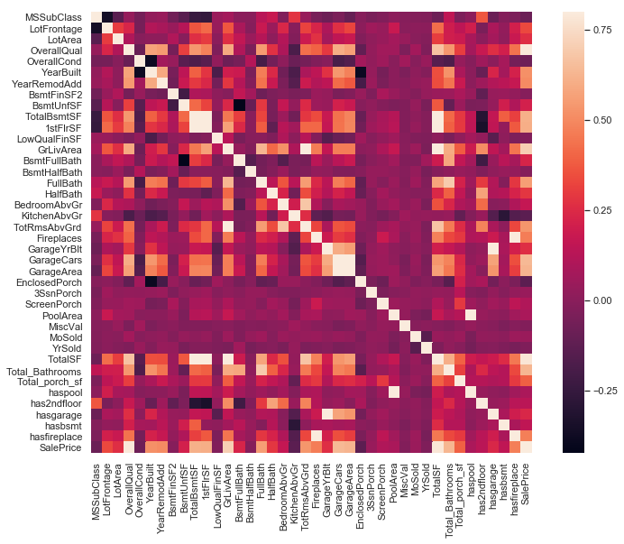

```python
#correlation matrix
corrmat = df.corr()
f, ax = plt.subplots(figsize=(12, 9))
sns.heatmap(corrmat, vmax=.8, square=True);
```

This is a great way to get a quick overview of our data and its relationships.

Another thing that got my attention was the 'SalePrice' correlations. We can see 'TotalSF', 'GrLivArea', 'TotalBsmtSF', and 'OverallQual' with significant relationships with 'SalePrice', but we can also see many other variables that should be taken into account. That's what we will do next.

#### 'SalePrice' correlation matrix (zoomed heatmap)

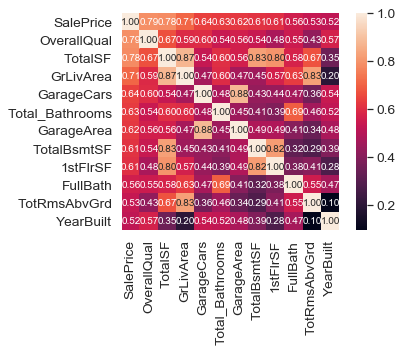

```python
#saleprice correlation matrix
k = 12 #number of variables for heatmap
cols = corrmat.nlargest(k, 'SalePrice')['SalePrice'].index
cm = np.corrcoef(df[cols].values.T)
sns.set(font_scale=1.25)
hm = sns.heatmap(cm, cbar=True, annot=True, square=True, fmt='.2f', annot_kws={'size': 10}, yticklabels=cols.values, xticklabels=cols.values)
plt.show()
```

Let's proceed to the scatter plots.

#### Scatter plots between 'SalePrice' and correlated variables

```python
# Not normaly distributed can not be normalised and has no central tendecy
features = features.drop(columns=['GrLivArea','GarageArea','1stFlrSF'])
df = df.drop(columns=['GrLivArea','GarageArea','1stFlrSF'])
```

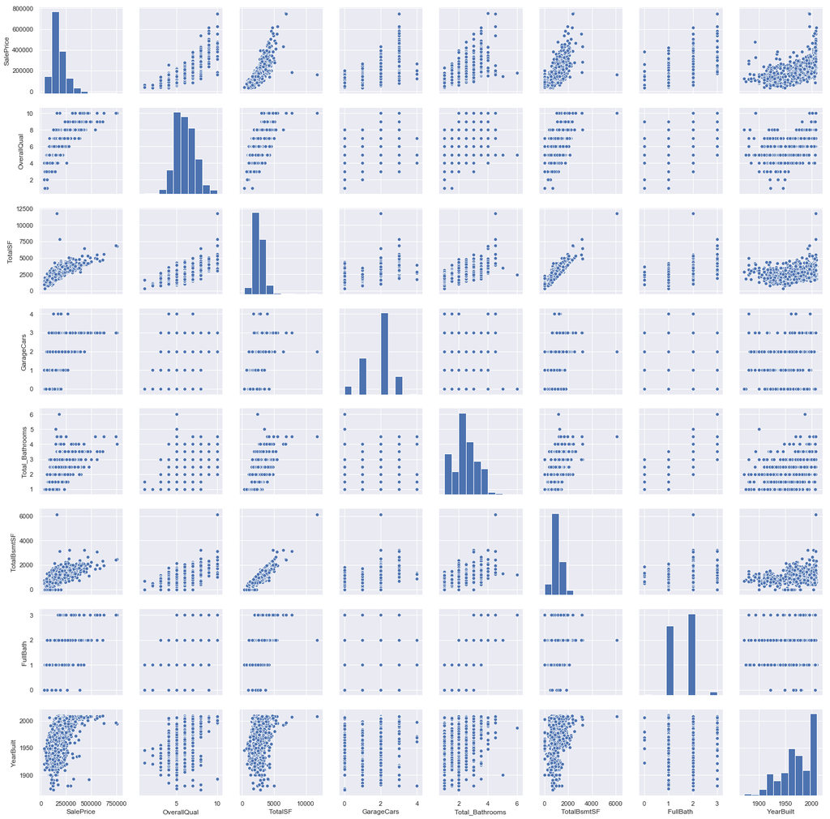

```python
#scatterplot
sns.set()
cols = ['SalePrice','OverallQual', 'TotalSF', 'GarageCars',
        'Total_Bathrooms','TotalBsmtSF', 'FullBath', 'YearBuilt']
sns.pairplot(df[cols], height = 2.5)
plt.show();
```

Although we already know some of the main figures, this mega scatter plot gives us a reasonable idea about variables relationships.

One of the figures we may find interesting is the one between 'TotalBsmtSF' and 'TotalSF'. In this figure we can see the dots drawing a linear line, which almost acts like a border. It totally makes sense that the majority of the dots stay below that line. Basement areas can be equal to the Total square footage, but it is not expected a basement area bigger than the total living area (unless you're trying to buy a bunker).

The plot concerning 'SalePrice' and 'YearBuilt' can also make us think. In the bottom of the 'dots cloud', we see what almost appears to be a shy exponential function. We can also see this same tendency in the upper limit of the 'dots cloud'. Also, notice how the set of dots regarding the last years tend to stay above this limit (I just wanted to say that prices are increasing faster now).

## 5. Data Preprocessing

### Target variable: Sales price Skew & kurtosis analysis

As `SalePrice` is the most important variable of this project, therefore it should be inspected thoroughly.

Let's take a look at the distribution of this variable:

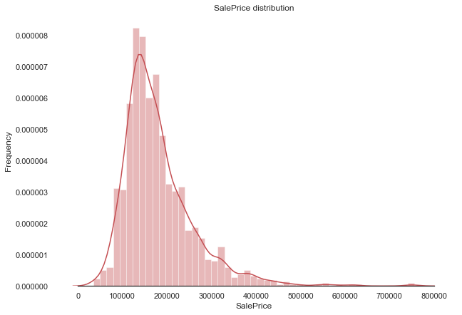

```
Skewness: 1.882876
Kurtosis: 6.536282
```

```python
#Before the normalisation
sns.set_style("white")
sns.set_color_codes(palette='deep')
f, ax = plt.subplots(figsize=(10, 7))
#Check the new distribution
sns.distplot(train['SalePrice'], color="r");
ax.xaxis.grid(False)
ax.set(ylabel="Frequency")
ax.set(xlabel="SalePrice")
ax.set(title="SalePrice distribution")
sns.despine(trim=True, left=True)
plt.show()

#skewness and kurtosis
print("Skewness: %f" % train['SalePrice'].skew())
print("Kurtosis: %f" % train['SalePrice'].kurt())
```

On this graph we see a long right tail on `SalePrice` atribute. It is clearly not normally distributted.

This is a problem because a lot of regression models like working with normal distributions and perform better this way. There are several ways that this could be handled. We are going to do a log transformation on our `SalePrice` and see if it normalizes our distribution.

#### Skew

$$skew (X) = E \left(\frac{X-\mu}{\sigma} \right)^3$$

[figure not shown]

#### Kurtosis

$$kurtosis (X) = E \left(\frac{X-\mu}{\sigma} \right)^4$$

[figure not shown]

#### Transformation

Let's try the following tranformation to correct the skew

$$ Y = log(1+X) $$

We can check a random example of a different log transformation:

[figure not shown]

This is to make sure that SalesPrice values are distributed normaly using function log1p which applies log(1+x) to all elements of the column which fixes the skeweness of the distribution.

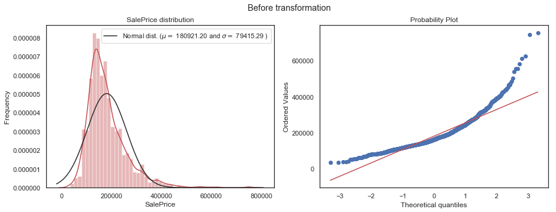

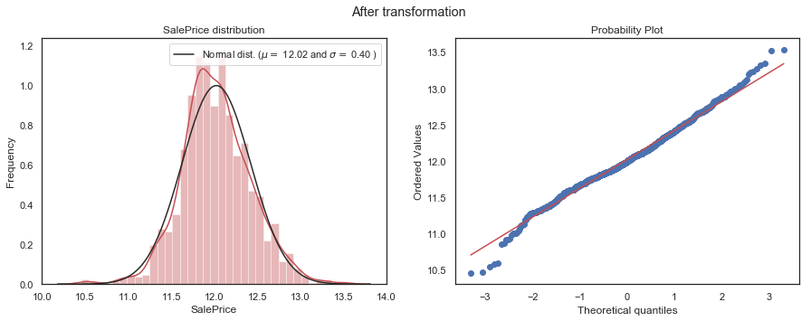

```python
# Plot histogram and probability
fig = plt.figure(figsize=(15,5))
plt.subplot(1,2,1)
sns.distplot(train['SalePrice'] , fit=norm, color="r");
(mu, sigma) = norm.fit(train['SalePrice'])
plt.legend(['Normal dist. ($\mu=$ {:.2f} and $\sigma=$ {:.2f} )'.format(mu, sigma)],
            loc='best')
plt.ylabel('Frequency')
plt.title('SalePrice distribution')
plt.subplot(1,2,2)
res = stats.probplot(train['SalePrice'], plot=plt)
plt.suptitle('Before transformation')

# Apply transformation
train.SalePrice = np.log1p(train.SalePrice)
# New prediction
y_train = train.SalePrice.values
y_train_orig = train.SalePrice

# Plot histogram and probability after transformation
fig = plt.figure(figsize=(15,5))
plt.subplot(1,2,1)
sns.distplot(train['SalePrice'] , fit=norm, color="r");
(mu, sigma) = norm.fit(train['SalePrice'])
plt.legend(['Normal dist. ($\mu=$ {:.2f} and $\sigma=$ {:.2f} )'.format(mu, sigma)],
            loc='best')
plt.ylabel('Frequency')
plt.title('SalePrice distribution')
plt.subplot(1,2,2)
res = stats.probplot(train['SalePrice'], plot=plt)
plt.suptitle('After transformation');
```

Our distribution looks much more normal now after a log transformation. We are going to go ahead and use our models to predict the log of `SalePrice` now and we will just have to make sure to change our predictions back to dollars when we are done.

#### Box cox transform for skewd numerical data

Now we are going to take care of the skew that we noticed in some of our predictor variables earlier. We will identify which ones are skewed in a mathematical way. We will use the scipy stats package to do this, then we will use a boxcox transformation to fix any of the skewed variables that we identify.

Equation:

[figure not shown]

Transformation example:

[figure not shown]

```python
# Differentiate numerical features (minus the target) and categorical features
categorical_features = features.select_dtypes(include=['category']).columns
print(categorical_features)
numerical_features = features.select_dtypes(exclude = ['category']).columns
print(numerical_features)

print("Numerical features : " + str(len(numerical_features)))
print("Categorical features : " + str(len(categorical_features)))
feat_num = features[numerical_features]
feat_cat = features[categorical_features]
```

```
Index(['MSZoning', 'Street', 'Alley', 'LotShape', 'LandContour', 'Utilities',
       'LotConfig', 'LandSlope', 'Neighborhood', 'Condition1', 'Condition2',
       'BldgType', 'HouseStyle', 'RoofStyle', 'RoofMatl', 'Exterior1st',
       'Exterior2nd', 'MasVnrType', 'ExterQual', 'ExterCond', 'Foundation',
       'BsmtQual', 'BsmtCond', 'BsmtExposure', 'BsmtFinType1', 'BsmtFinType2',
       'Heating', 'HeatingQC', 'CentralAir', 'Electrical', 'KitchenQual',
       'Functional', 'FireplaceQu', 'GarageType', 'GarageFinish', 'GarageQual',
       'GarageCond', 'PavedDrive', 'PoolQC', 'Fence', 'MiscFeature',
       'SaleType', 'SaleCondition'],
      dtype='object')
Index(['MSSubClass', 'LotFrontage', 'LotArea', 'OverallQual', 'OverallCond',
       'YearBuilt', 'YearRemodAdd', 'BsmtFinSF2', 'BsmtUnfSF', 'TotalBsmtSF',
       'LowQualFinSF', 'BsmtFullBath', 'BsmtHalfBath', 'FullBath', 'HalfBath',
       'BedroomAbvGr', 'KitchenAbvGr', 'TotRmsAbvGrd', 'Fireplaces',
       'GarageYrBlt', 'GarageCars', 'EnclosedPorch', '3SsnPorch',
       'ScreenPorch', 'PoolArea', 'MiscVal', 'MoSold', 'YrSold', 'TotalSF',
       'Total_Bathrooms', 'Total_porch_sf', 'haspool', 'has2ndfloor',
       'hasgarage', 'hasbsmt', 'hasfireplace'],
      dtype='object')
Numerical features : 36
Categorical features : 43
```

```python
feat_num.head()
```

|  | MSSubClass | LotFrontage | LotArea | OverallQual | OverallCond | YearBuilt | YearRemodAdd | BsmtFinSF2 | BsmtUnfSF | TotalBsmtSF | LowQualFinSF | BsmtFullBath | BsmtHalfBath | FullBath | HalfBath | BedroomAbvGr | KitchenAbvGr | TotRmsAbvGrd | Fireplaces | GarageYrBlt | GarageCars | EnclosedPorch | 3SsnPorch | ScreenPorch | PoolArea | MiscVal | MoSold | YrSold | TotalSF | … |
| --- | --- | --- | --- | --- | --- | --- | --- | --- | --- | --- | --- | --- | --- | --- | --- | --- | --- | --- | --- | --- | --- | --- | --- | --- | --- | --- | --- | --- | --- | --- |
| 0 | 60 | 65 | 8450 | 7 | 5 | 2003 | 2003 | 0 | 150 | 856 | 0 | 1 | 0 | 2 | 1 | 3 | 1 | 8 | 0 | 2003 | 2 | 0 | 0 | 0 | 0 | 0 | 2 | 2008 | 2566.0 | … |
| 1 | 20 | 80 | 9600 | 6 | 8 | 1976 | 1976 | 0 | 284 | 1262 | 0 | 0 | 1 | 2 | 0 | 3 | 1 | 6 | 1 | 1976 | 2 | 0 | 0 | 0 | 0 | 0 | 5 | 2007 | 2524.0 | … |
| 2 | 60 | 68 | 11250 | 7 | 5 | 2001 | 2002 | 0 | 434 | 920 | 0 | 1 | 0 | 2 | 1 | 3 | 1 | 6 | 1 | 2001 | 2 | 0 | 0 | 0 | 0 | 0 | 9 | 2008 | 2706.0 | … |
| 3 | 70 | 60 | 9550 | 7 | 5 | 1915 | 1970 | 0 | 540 | 756 | 0 | 1 | 0 | 1 | 0 | 3 | 1 | 7 | 1 | 1998 | 3 | 272 | 0 | 0 | 0 | 0 | 2 | 2006 | 2473.0 | … |
| 4 | 60 | 84 | 14260 | 8 | 5 | 2000 | 2000 | 0 | 490 | 1145 | 0 | 1 | 0 | 2 | 1 | 4 | 1 | 9 | 1 | 2000 | 3 | 0 | 0 | 0 | 0 | 0 | 12 | 2008 | 3343.0 | … |

```python
feat_cat.head()
```

|  | MSZoning | Street | Alley | LotShape | LandContour | Utilities | LotConfig | LandSlope | Neighborhood | Condition1 | Condition2 | BldgType | HouseStyle | RoofStyle | RoofMatl | Exterior1st | Exterior2nd | MasVnrType | ExterQual | ExterCond | Foundation | BsmtQual | BsmtCond | BsmtExposure | BsmtFinType1 | BsmtFinType2 | Heating | HeatingQC | CentralAir | … |
| --- | --- | --- | --- | --- | --- | --- | --- | --- | --- | --- | --- | --- | --- | --- | --- | --- | --- | --- | --- | --- | --- | --- | --- | --- | --- | --- | --- | --- | --- | --- |
| 0 | RL | Pave | None | Reg | Lvl | AllPub | Inside | Gtl | CollgCr | Norm | Norm | 1Fam | 2Story | Gable | CompShg | VinylSd | VinylSd | BrkFace | Gd | TA | PConc | Gd | TA | No | GLQ | Unf | GasA | Ex | Y | … |
| 1 | RL | Pave | None | Reg | Lvl | AllPub | FR2 | Gtl | Veenker | Feedr | Norm | 1Fam | 1Story | Gable | CompShg | MetalSd | MetalSd | None | TA | TA | CBlock | Gd | TA | Gd | ALQ | Unf | GasA | Ex | Y | … |
| 2 | RL | Pave | None | IR1 | Lvl | AllPub | Inside | Gtl | CollgCr | Norm | Norm | 1Fam | 2Story | Gable | CompShg | VinylSd | VinylSd | BrkFace | Gd | TA | PConc | Gd | TA | Mn | GLQ | Unf | GasA | Ex | Y | … |
| 3 | RL | Pave | None | IR1 | Lvl | AllPub | Corner | Gtl | Crawfor | Norm | Norm | 1Fam | 2Story | Gable | CompShg | Wd Sdng | Wd Shng | None | TA | TA | BrkTil | TA | Gd | No | ALQ | Unf | GasA | Gd | Y | … |
| 4 | RL | Pave | None | IR1 | Lvl | AllPub | FR2 | Gtl | NoRidge | Norm | Norm | 1Fam | 2Story | Gable | CompShg | VinylSd | VinylSd | BrkFace | Gd | TA | PConc | Gd | TA | Av | GLQ | Unf | GasA | Ex | Y | … |

```python
# Plot skew value for each numerical value
skewness = feat_num.apply(lambda x: skew(x))
skewness.sort_values(ascending=False)
```

```
MiscVal            21.947195
PoolArea           16.898328
haspool            14.884318
LotArea            12.822431
LowQualFinSF       12.088761
3SsnPorch          11.376065
KitchenAbvGr        4.302254
BsmtFinSF2          4.146143
EnclosedPorch       4.003891
ScreenPorch         3.946694
BsmtHalfBath        3.931594
LotFrontage         1.674852
TotalSF             1.511479
Total_porch_sf      1.376649
MSSubClass          1.375457
TotalBsmtSF         1.156894
BsmtUnfSF           0.919339
TotRmsAbvGrd        0.758367
Fireplaces          0.733495
HalfBath            0.694566
BsmtFullBath        0.624832
OverallCond         0.570312
Total_Bathrooms     0.492247
BedroomAbvGr        0.326324
has2ndfloor         0.288675
OverallQual         0.197110
MoSold              0.195884
FullBath            0.167606
YrSold              0.132399
hasfireplace       -0.054148
GarageCars         -0.219581
YearRemodAdd       -0.451020
YearBuilt          -0.599806
GarageYrBlt        -3.906205
hasgarage          -3.941054
hasbsmt            -5.828995
dtype: float64
```

```python
skewness = skewness.loc[abs(skewness) > 0.75]
print("There are {} skewed numerical features to Box Cox transform".format(skewness.shape[0]))
print("Mean skewnees: {}".format(np.mean(skewness)))

skewed_features = skewness.index
lam = 0.15
for feat in skewed_features:
    features.loc[:,feat] = boxcox1p(features.loc[:,feat], lam)

skewness.sort_values(ascending=False)
```

```
There are 21 skewed numerical features to Box Cox transform
Mean skewnees: 5.021164634971275
```

```
MiscVal           21.947195
PoolArea          16.898328
haspool           14.884318
LotArea           12.822431
LowQualFinSF      12.088761
3SsnPorch         11.376065
KitchenAbvGr       4.302254
BsmtFinSF2         4.146143
EnclosedPorch      4.003891
ScreenPorch        3.946694
BsmtHalfBath       3.931594
LotFrontage        1.674852
TotalSF            1.511479
Total_porch_sf     1.376649
MSSubClass         1.375457
TotalBsmtSF        1.156894
BsmtUnfSF          0.919339
TotRmsAbvGrd       0.758367
GarageYrBlt       -3.906205
hasgarage         -3.941054
hasbsmt           -5.828995
dtype: float64
```

```python
# Shape before apply get_dummies
print('shape before get_dummies:',features.shape)

#Get dummy variables
features = pd.get_dummies(features)

# New shape of data
print('new shape:',features.shape)
```

```
shape before get_dummies: (2919, 79)
new shape: (2919, 303)
```

## 4. Model Selection & Hyperparameter Tuning

We will test the following models (based on the scikit-learn algorithm cheat-sheet):

- Ridge
- Lasso
- ElasticNet
- XGBoost
- RandomForest

[figure not shown]

```python
features.head()
```

|  | MSSubClass | LotFrontage | LotArea | OverallQual | OverallCond | YearBuilt | YearRemodAdd | BsmtFinSF2 | BsmtUnfSF | TotalBsmtSF | LowQualFinSF | BsmtFullBath | BsmtHalfBath | FullBath | HalfBath | BedroomAbvGr | KitchenAbvGr | TotRmsAbvGrd | Fireplaces | GarageYrBlt | GarageCars | EnclosedPorch | 3SsnPorch | ScreenPorch | PoolArea | MiscVal | MoSold | YrSold | TotalSF | … |
| --- | --- | --- | --- | --- | --- | --- | --- | --- | --- | --- | --- | --- | --- | --- | --- | --- | --- | --- | --- | --- | --- | --- | --- | --- | --- | --- | --- | --- | --- | --- |
| 0 | 5.684507 | 5.831328 | 19.212182 | 7 | 5 | 2003 | 2003 | 0.0 | 7.483296 | 11.692623 | 0.0 | 1 | 0.000000 | 2 | 1 | 3 | 0.730463 | 2.602594 | 0 | 14.187527 | 2 | 0.000000 | 0.0 | 0.0 | 0.0 | 0.0 | 2 | 2008 | 14.976591 | … |
| 1 | 3.858807 | 6.221214 | 19.712205 | 6 | 8 | 1976 | 1976 | 0.0 | 8.897844 | 12.792276 | 0.0 | 0 | 0.730463 | 2 | 0 | 3 | 0.730463 | 2.259674 | 1 | 14.145138 | 2 | 0.000000 | 0.0 | 0.0 | 0.0 | 0.0 | 5 | 2007 | 14.923100 | … |
| 2 | 5.684507 | 5.914940 | 20.347241 | 7 | 5 | 2001 | 2002 | 0.0 | 9.917060 | 11.892039 | 0.0 | 1 | 0.000000 | 2 | 1 | 3 | 0.730463 | 2.259674 | 1 | 14.184404 | 2 | 0.000000 | 0.0 | 0.0 | 0.0 | 0.0 | 9 | 2008 | 15.149678 | … |
| 3 | 5.968981 | 5.684507 | 19.691553 | 7 | 5 | 1915 | 1970 | 0.0 | 10.468500 | 11.354094 | 0.0 | 1 | 0.000000 | 1 | 0 | 3 | 0.730463 | 2.440268 | 1 | 14.179714 | 3 | 8.797736 | 0.0 | 0.0 | 0.0 | 0.0 | 2 | 2006 | 14.857121 | … |
| 4 | 5.684507 | 6.314735 | 21.325160 | 8 | 5 | 2000 | 2000 | 0.0 | 10.221051 | 12.510588 | 0.0 | 1 | 0.000000 | 2 | 1 | 4 | 0.730463 | 2.750250 | 1 | 14.182841 | 3 | 0.000000 | 0.0 | 0.0 | 0.0 | 0.0 | 12 | 2008 | 15.852312 | … |

```python
X = features.iloc[:n_train,:]
X_test = features.iloc[n_train:,:]

print('X:',X.shape)
print('X_test:',X_test.shape)
print('y_train:',y_train.shape)
```

```
X: (1460, 303)
X_test: (1459, 303)
y_train: (1460,)
```

#### Defining folds and score functions

We use the kfolds Cross Validation function where K=10 which is the number of holdout sets. The function has no shuffle attribute, we add then one line of code shuffle=True, in order to shuffle the dataset prior to cross-validation.

```python
kfolds = KFold(n_splits=10, shuffle=True, random_state=42)

# model scoring and validation function
def cv_rmse(model, X=X):
    rmse = np.sqrt(-cross_val_score(model, X, y_train,scoring="neg_mean_squared_error",cv=kfolds))
    return (rmse)

# rmsle scoring function
def rmsle(y_train, y_pred):
    return np.sqrt(mean_squared_error(y_train, y_pred))
```

#### Defining models and training models

```python
# setup models hyperparameters using a pipline
# The purpose of the pipeline is to assemble several steps that can be cross-validated together, while setting different parameters.
# This is a range of values that the model considers each time in runs a CV
e_alphas = [0.0001, 0.0002, 0.0003, 0.0004, 0.0005, 0.0006, 0.0007]
e_l1ratio = [0.8, 0.85, 0.9, 0.95, 0.99, 1]
alphas_alt = [14.5, 14.6, 14.7, 14.8, 14.9, 15, 15.1, 15.2, 15.3, 15.4, 15.5]
alphas2 = [5e-05, 0.0001, 0.0002, 0.0003, 0.0004, 0.0005, 0.0006, 0.0007, 0.0008]


# Kernel Ridge Regression : made robust to outliers
ridge = make_pipeline(RobustScaler(), RidgeCV(alphas=alphas_alt, cv=kfolds))

# LASSO Regression : made robust to outliers
lasso = make_pipeline(RobustScaler(), LassoCV(max_iter=1e7,
                    alphas=alphas2,random_state=42, cv=kfolds))

# Elastic Net Regression : made robust to outliers
elasticnet = make_pipeline(RobustScaler(), ElasticNetCV(max_iter=1e7,
                         alphas=e_alphas, cv=kfolds, l1_ratio=e_l1ratio))

# XGBoost
xgboost = XGBRegressor(learning_rate=0.01,n_estimators=3460,
                                     max_depth=3, min_child_weight=0,
                                     gamma=0, subsample=0.7,
                                     colsample_bytree=0.7,
                                     objective='reg:squarederror', nthread=-1,
                                     scale_pos_weight=1, seed=27,
                                     reg_alpha=0.00006)

# Random ForrestRegression
rforest = RandomForestRegressor(n_estimators=500)


# store models, scores and prediction values
models = {'Ridge': ridge,
          'Lasso': lasso,
          'ElasticNet': elasticnet,
          'XGBoost':xgboost,
          'RandomForest': rforest}
predictions = {}
scores = {}

for name, model in models.items():

    model.fit(X, y_train)
    predictions[name] = np.expm1(model.predict(X))

    score = cv_rmse(model, X=X)
    scores[name] = (score.mean(), score.std())
```

#### Validating and training each model

```python
# get the performance of each model on training data(validation set)
print('---- Score with CV_RMSLE-----')
score = cv_rmse(ridge)
print("Ridge score: {:.4f} ({:.4f})\n".format(score.mean(), score.std()))

score = cv_rmse(lasso)
print("Lasso score: {:.4f} ({:.4f})\n".format(score.mean(), score.std()))

score = cv_rmse(elasticnet)
print("ElasticNet score: {:.4f} ({:.4f})\n".format(score.mean(), score.std()))

score = cv_rmse(xgboost)
print("XGBoost score: {:.4f} ({:.4f})\n".format(score.mean(), score.std()))

score = cv_rmse(rforest)
print("RandomForest score {:.4f} ({:.4f})\n".format(score.mean(), score.std()))
```

```
---- Score with CV_RMSLE-----
Ridge score: 0.1271 (0.0256)

Lasso score: 0.1226 (0.0277)

ElasticNet score: 0.1226 (0.0277)

XGBoost score: 0.1163 (0.0175)

RandomForest score 0.1385 (0.0221)
```

#### Fit models

```python
#Fit the training data X, y
print('----START Fit----',datetime.now())
print('Elasticnet')
elastic_model = elasticnet.fit(X, y_train)
print('Lasso')
lasso_model = lasso.fit(X, y_train)
print('Ridge')
ridge_model = ridge.fit(X, y_train)
print('XGBoost')
xgb_model = xgboost.fit(X,y_train)
print('RandomForest')
rf_model = rforest.fit(X,y_train)
```

```
----START Fit---- 2019-09-05 11:25:34.290130
Elasticnet
Lasso
Ridge
XGBoost
RandomForest
```

## 5. Ensembling Models

```python
# model blending function using fitted models to make predictions
def blend_models(X):
    return ((elastic_model.predict(X)) + (lasso_model.predict(X)) + \
            (ridge_model.predict(X)) + xgb_model.predict(X) + rf_model.predict(X))/5
blended_score = rmsle(y_train, blend_models(X))
print('RMSLE score on train data:')
print(rmsle(y_train, blend_models(X)))
```

```
RMSLE score on train data:
0.08083201104871911
```

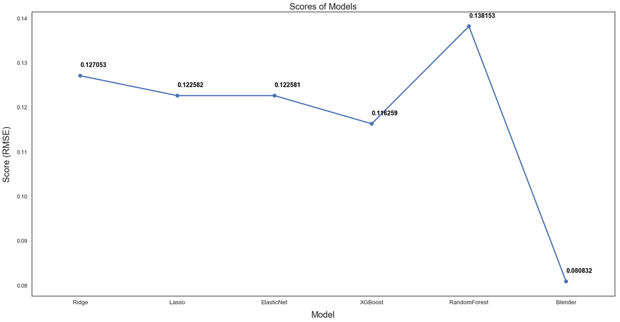

```python
scores['Blender'] = (blended_score, 0)
sns.set_style("white")
fig = plt.figure(figsize=(24, 12))

ax = sns.pointplot(x=list(scores.keys()), y=[score for score, _ in scores.values()], markers=['o'], linestyles=['-'])
for i, score in enumerate(scores.values()):
    ax.text(i, score[0] + 0.002, '{:.6f}'.format(score[0]), horizontalalignment='left', size='large', color='black', weight='semibold')

plt.ylabel('Score (RMSE)', size=20, labelpad=12.5)
plt.xlabel('Model', size=20, labelpad=12.5)
plt.tick_params(axis='x', labelsize=13.5)
plt.tick_params(axis='y', labelsize=12.5)

plt.title('Scores of Models', size=20)

plt.show()
```

## 6. Model Predictions

```python
print('Predict submission')
submission = pd.read_csv("source/sample_submission.csv")
submission.iloc[:,1] = (np.expm1(blend_models(X_test)))
```

```
Predict submission
```

## 7. Submission

```python
submission.to_csv("source/submission.csv", index=False)
print('Save submission', datetime.now(),)
```

```
Save submission 2019-09-05 11:26:11.238648
```